# Lecture 323

2021-11-30

## Comparing regression models

## Recap

**Prev**: Multiple Regression

- Multiple regression
- Interpretation
- Checking assumptions

**Now**: Comparing regression models

- Information criteria
- Model difference
- Stepwise selection
- Validation

## Multiple regression

**Regression analysis** is a supervised machine learning approach

Special case of the general linear model

\[outcome_i = (model) + error_i \]

Predict (estimate) value of one outcome (dependent) variable as

- one predictor (independent) variable: **simple / univariate**

\[Y_i = (b_0 + b_1 * X_{i1}) + \epsilon_i \]

- more predictor (independent) variables: **multiple / multivar.**

\[Y_i = (b_0 + b_1 * X_{i1} + b_2 * X_{i2} + \dots + b_M * X_{iM}) + \epsilon_i \]

## Example

Can we predict price based on number of rooms and air quality?

\[house\ value_i = (b_0 + b_1 * rooms_{i} + b_1 * NO\ conc_{i}) + \epsilon_i \]

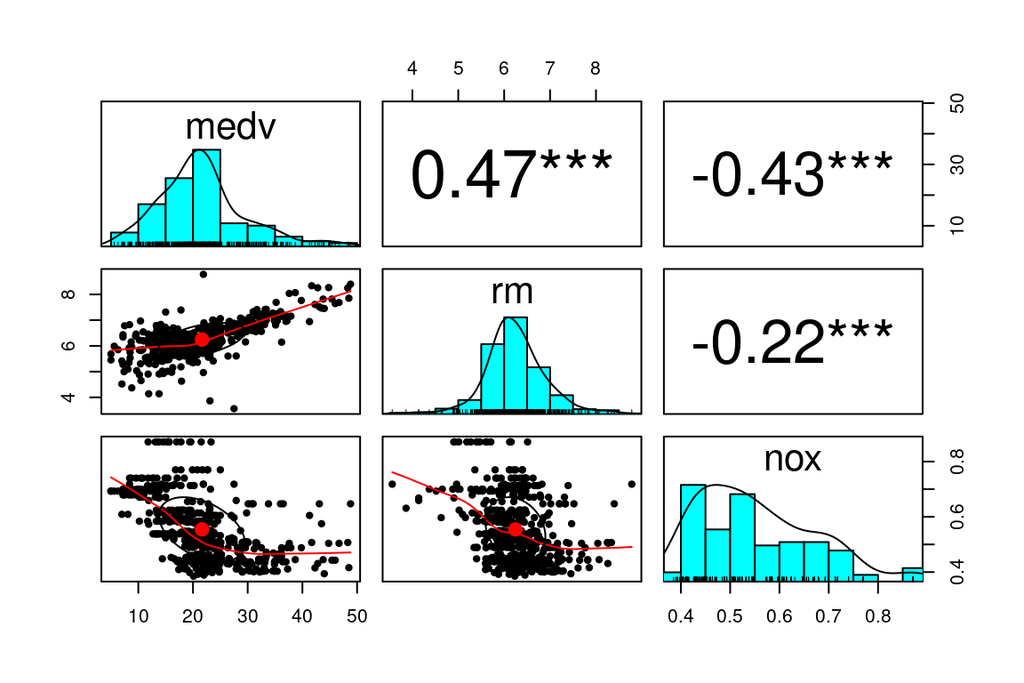

## stats::lm

```r
MASS::Boston %>% filter(medv < 50) %$%
  stats::lm(medv ~ rm + nox) ->
  medv_model1

medv_model1 %>%
  summary()
```

```
##
## Call:
## stats::lm(formula = medv ~ rm + nox)
##
## Residuals:
##      Min       1Q   Median       3Q      Max
## -15.0255  -2.8916  -0.3794   2.6363  28.2653
##
## Coefficients:
##             Estimate Std. Error t value Pr(>|t|)
## (Intercept)  -9.1677     2.9516  -3.106  0.00201 **
## rm            6.9550     0.3763  18.481  < 2e-16 ***
## nox         -22.7914     2.1064 -10.820  < 2e-16 ***
## ---
## Signif. codes:  0 '***' 0.001 '**' 0.01 '*' 0.05 '.' 0.1 ' ' 1
##
## Residual standard error: 5.145 on 487 degrees of freedom
## Multiple R-squared:  0.5739, Adjusted R-squared:  0.5721
## F-statistic:   328 on 2 and 487 DF,  p-value: < 2.2e-16
```

## Checking assumptions

```
##
##  Shapiro-Wilk normality test
##
## data:  .
## W = 0.96913, p-value = 1.222e-08
```

```
##
##  studentized Breusch-Pagan test
##
## data:  .
## BP = 38.776, df = 2, p-value = 3.8e-09
```

```
##
##  Durbin-Watson test
##
## data:  .
## DW = 0.80228, p-value < 2.2e-16
## alternative hypothesis: true autocorrelation is greater than 0
```

```
##       rm      nox
## 1.116167 1.116167
```

## Model 1

No, we can’t predict house prices based only on number of rooms and air quality.

- predictors are statistically significant
- but model is not robust, as it doesn’t satisfy most assumptions
  - Standard residuals are NOT normally distributed
  - Standard residuals are NOT homoscedastic
  - Standard residuals are NOT independent
  - (although there is no multicollinearity)

We seem to be on the right path, but something is missing…

## stats::lm

```r
MASS::Boston %>% filter(medv < 50) %$%
  stats::lm(medv ~ rm + nox + ptratio + log(crim)) ->
  medv_model2

medv_model2 %>%
  summary()
```

```
##
## Call:
## stats::lm(formula = medv ~ rm + nox + ptratio + log(crim))
##
## Residuals:
##      Min       1Q   Median       3Q      Max
## -12.1957  -2.7435  -0.1094   2.2879  26.9646
##
## Coefficients:
##             Estimate Std. Error t value Pr(>|t|)
## (Intercept)  10.4676     4.0846   2.563 0.010687 *
## rm            5.9404     0.3421  17.366  < 2e-16 ***
## nox         -13.0203     2.9408  -4.427 1.18e-05 ***
## ptratio      -1.0344     0.1107  -9.345  < 2e-16 ***
## log(crim)    -0.5558     0.1676  -3.316 0.000983 ***
## ---
## Signif. codes:  0 '***' 0.001 '**' 0.01 '*' 0.05 '.' 0.1 ' ' 1
##
## Residual standard error: 4.526 on 485 degrees of freedom
## Multiple R-squared:  0.6715, Adjusted R-squared:  0.6688
## F-statistic: 247.9 on 4 and 485 DF,  p-value: < 2.2e-16
```

## Logarithmic transformations

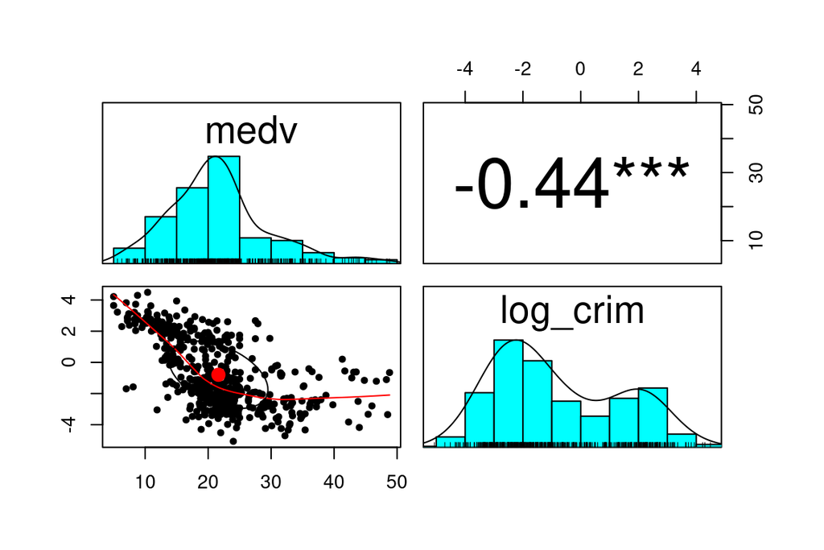

## Checking assumptions

```
##
##  Shapiro-Wilk normality test
##
## data:  .
## W = 0.95777, p-value = 1.231e-10
```

```
##
##  studentized Breusch-Pagan test
##
## data:  .
## BP = 14.78, df = 4, p-value = 0.005179
```

```
##
##  Durbin-Watson test
##
## data:  .
## DW = 0.99915, p-value < 2.2e-16
## alternative hypothesis: true autocorrelation is greater than 0
```

```
##        rm       nox   ptratio log(crim)
##  1.191368  2.810505  1.302618  3.125288
```

## Model 2

No, we still can’t robustly predict house prices based on number of rooms, air quality, student/teacher ratio and crime level.

- predictors are statistically significant
- but model is not robust
  - Standard residuals are NOT normally distributed
  - Standard residuals are NOT homoscedastic
  - Standard residuals are NOT independent
  - There is some sign of multicollinearity

Still possibly on the right path, not quite there yet…

Is there a difference between:

- Model1’s \(R^2 =\) 0.5721 and Model2’s \(R^2 =\) 0.6688?

## Comparing R-squared

- \(R^2\)
  - measure of correlation between
    - values predicted by the model (fitted values)
    - observed values for outcome variable
- Adjusted \(R^2\)
  - adjusts the \(R^2\) depending on
    - number of cases
    - number of predictor (independent) variables
  - *“unnecessary”* variables lower the value

The model with the highest adjusted \(R^2\) has the best fit

## Model difference with ANOVA

Can be used to test whether adjusted \(R^2\) are signif. different

- if models are hierarchical
  - one uses all variables of the other
  - plus some additional variables

```r
stats::anova(medv_model1, medv_model2)
```

```
## Analysis of Variance Table
##
## Model 1: medv ~ rm + nox
## Model 2: medv ~ rm + nox + ptratio + log(crim)
##   Res.Df     RSS Df Sum of Sq      F    Pr(>F)
## 1    487 12890.0
## 2    485  9936.7  2    2953.3 72.073 < 2.2e-16 ***
## ---
## Signif. codes:  0 '***' 0.001 '**' 0.01 '*' 0.05 '.' 0.1 ' ' 1
```

Still, neither model is robust

## Information criteria

- Akaike Information Criterion (**AIC**)
  - measure of model fit
    - penalising model with more variables
  - not interpretable per-se, used to compare similar models
    - lower value, better fit
- Bayesian Information Criterion (**BIC**)
  - similar to AIC

```r
stats::AIC(medv_model1)
```

```
## [1] 3000.763
```

```r
stats::AIC(medv_model2)
```

```
## [1] 2877.258
```

## Stepwise selection

**Stepwise selection** of predictor (independent) variables

- iteratively adding and/or removing predictors
- to obtain best performing model

Three approaches

- forward: from no variable, iteratively add variables
- backward: from all variables, iteratively remove variables
- both (a.k.a. step-wise):
  - from no variable
  - one step forward, add most promising variable
  - one step backward, remove any variable not improving

## MASS::stepAIC

```r
MASS::Boston %$%
  MASS::stepAIC(
    object =
      lm(medv ~ 1),
    scope =
      medv ~
        crim + zn + indus + chas + rm + nox + age +
        dis + rad + tax + ptratio + black + lstat,
    direction = "both",
    trace = FALSE
  ) ->
  medv_model3

medv_model3 %>%
  summary()
```

## Model 3

```
##
## Call:
## lm(formula = medv ~ lstat + rm + ptratio + dis + nox + chas +
##     black + zn + crim + rad + tax)
##
## Residuals:
##      Min       1Q   Median       3Q      Max
## -15.5984  -2.7386  -0.5046   1.7273  26.2373
##
## Coefficients:
##               Estimate Std. Error t value Pr(>|t|)
## (Intercept)  36.341145   5.067492   7.171 2.73e-12 ***
## lstat        -0.522553   0.047424 -11.019  < 2e-16 ***
## rm            3.801579   0.406316   9.356  < 2e-16 ***
## ptratio      -0.946525   0.129066  -7.334 9.24e-13 ***
## dis          -1.492711   0.185731  -8.037 6.84e-15 ***
## nox         -17.376023   3.535243  -4.915 1.21e-06 ***
## chas          2.718716   0.854240   3.183 0.001551 **
## black         0.009291   0.002674   3.475 0.000557 ***
## zn            0.045845   0.013523   3.390 0.000754 ***
## crim         -0.108413   0.032779  -3.307 0.001010 **
## rad           0.299608   0.063402   4.726 3.00e-06 ***
## tax          -0.011778   0.003372  -3.493 0.000521 ***
## ---
## Signif. codes:  0 '***' 0.001 '**' 0.01 '*' 0.05 '.' 0.1 ' ' 1
##
## Residual standard error: 4.736 on 494 degrees of freedom
## Multiple R-squared:  0.7406, Adjusted R-squared:  0.7348
## F-statistic: 128.2 on 11 and 494 DF,  p-value: < 2.2e-16
```

## Checking assumptions

```
##
##  Shapiro-Wilk normality test
##
## data:  .
## W = 0.89904, p-value < 2.2e-16
```

```
##
##  studentized Breusch-Pagan test
##
## data:  .
## BP = 59.907, df = 11, p-value = 9.647e-09
```

```
##
##  Durbin-Watson test
##
## data:  .
## DW = 1.0779, p-value < 2.2e-16
## alternative hypothesis: true autocorrelation is greater than 0
```

```
##    lstat       rm  ptratio      dis      nox     chas    black
## 2.581984 1.834806 1.757681 3.443420 3.778011 1.059819 1.341559
##       zn     crim      rad      tax
## 2.239229 1.789704 6.861126 7.272386
```

## Validation

Can the model be generalised?

- split data into
  - training set: used to train the model
  - test set: used to test the model

Approaches:

- Validation
  - simple split: e.g. 80% traning, 20% test
- Cross-validation
  - leave-p-out: repeated split, leaving out p cases for test
    - leave-1-out
  - k-fold: repeated split, k equal size samples

## caret::train

Use caret::train to cross-validate Model 3

```r
library(caret)

train(
  formula(medv_model3),
  data = MASS::Boston,
  trControl = trainControl(
    method = "cv", # crossvalidate
    number = 5 # folds
  ),
  method = "lm", # regression model
  na.action = na.pass
) ->
medv_model3_crossv
```

## Crossvalidate Model 3

```r
medv_model3_crossv
```

```
## Linear Regression
##
## 506 samples
##  11 predictor
##
## No pre-processing
## Resampling: Cross-Validated (5 fold)
## Summary of sample sizes: 403, 406, 405, 406, 404
## Resampling results:
##
##   RMSE     Rsquared  MAE
##   4.79003  0.729601  3.332228
##
## Tuning parameter 'intercept' was held constant at a value of TRUE
```

```r
medv_model3_crossv$resample
```

```
##       RMSE  Rsquared      MAE Resample
## 1 4.521453 0.7398752 3.190820    Fold1
## 2 5.343629 0.7144533 3.408707    Fold2
## 3 4.248468 0.8004829 2.981942    Fold3
## 4 4.780203 0.6512789 3.189664    Fold4
## 5 5.056398 0.7419147 3.890007    Fold5
```

## Summary

Comparing regression models

- Information criteria
- Model difference
- Stepwise selection
- Validation

**Next**: Practical session

- Simple regression
- Multiple regression